# Accessing the Power of materializeR

Kent Russell

2015-05-01

# materializeR | materialize for R

[materialize](http://materializecss.com) implements Google’s Material Design in a CSS/JS/HTML framework. It is built by a talented [team of Carnegie Mellon Students](http://materializecss.com/about.html#team) and has amassed **> 8,000 stars** in less than half a year. Although I have been watching it closely since its release, [Alex Bresler](http://asbcllc.com/) deserves the credit for motivating me to assemble this little `htmlwidget`.

## Not a normal htmlwidget

Since `materialize` is a very full-featured and complete framework, the traditional full wrapping of an `htmlwidget` is nearly impossible. This `htmlwidget` seeks to provide a thin convenience layer primarily aimed to ease dependency injection for the required Javascript and CSS. What this means is that **you will need to know some `HTML/JS/CSS`** or copy/paste well to make it work. Also, [`htmltools`](http://github.com/rstudio/htmltools) and/or `Shiny` are/is a highly recommended companion to `materializeR`.

## Install and use

`materializeR` is not on CRAN, so install with `devtools::install_github`.

```r
devtools::install_github("timelyportfolio/materializeR")
```

There is just one function `materialize` to make it work. When you type it, you might be disappointed, but behind that blank screen is a world of potential backed by all the power of `materialize` and `jquery`. Of course, also remember `htmlwidgets` are pretty smart about conflict resolution, so this should only enhance your experience.

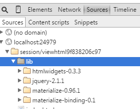

At this point the [documentation for materialize](http://materializecss.com/badges.html) will most likely be far more helpful than anything I put together. However, here a couple quick examples to demonstrate the translation and illustrate different techniques to incorporate `materializeR`. I will try to make these very `R` specific uses of the `materialize` examples.

### Simple grid

It seems that a minimum requirement for a front-end framework is a grid. We’ll prove that we can do it in `materializeR`. In this example, I’ll just copy and paste the example markup and supply it to a `tagList` from `htmltools` that also contains the command `materialize()`.

```r
library(htmltools)
library(materializeR)

tagList(
  HTML(
    '
    <div class="row" style = "font-weight: 200;line-height: 50px; text-align:center;">
      <div class="col s12" style = "background-color:tomato;margin:7px 0;border: 1px solid #eee;">
        <span class="flow-text">This div is 12-columns wide</span>
      </div>
      <div class="col s6" style = "background-color:tomato;margin:7px 0;border: 1px solid #eee;">
        <span class="flow-text">This div is 6-columns wide</span>
      </div>
      <div class="col s6" style = "background-color:tomato;margin:7px 0;border: 1px solid #eee;">
        <span class="flow-text">This div is 6-columns wide</span>
      </div>
    </div>
    '
  )
  ,materialize() # can be anywhere; doesn't have to be first
)
```

This div is 12-columns wide

This div is 6-columns wide

This div is 6-columns wide

[interactive chart not shown]

### Card with R plot and code

For this one, we’ll use `tags` from `htmltools`. `tags` sort-of self-check themselves. This is handy when we are trying to make HTML in R.

```r
library(htmltools)
library(materializeR)


# make a graph and save as png
tf <- tempfile()
png( file = tf, height = 400, width = 600 )
filled.contour(volcano)
dev.off()
```

[interactive chart not shown]

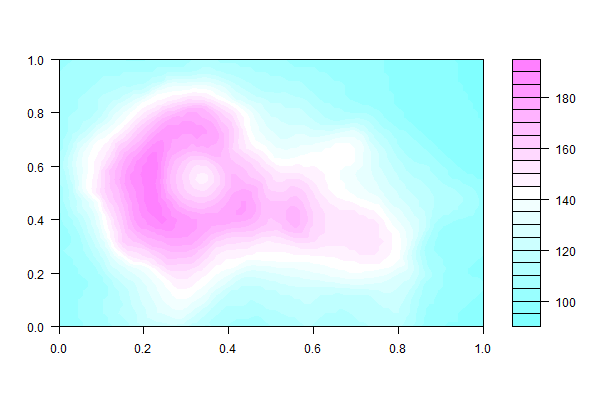

```r
tagList(
  materialize() # can be anywhere; doesn't have to be first
  ,tags$div(class = "card"
    ,tags$div(class = "card-image waves-effect waves-block waves-light"
      ,tags$img(class = "activator"
        ,src = paste0("data:…",base64enc::base64encode(tf))
      )
    )
    ,tags$div(class = "card-content"
      ,tags$span(class="card-title activator grey-text text-darken-4"
        ,"R plot from base graphics"
        ,tags$i( class="mdi-navigation-more-vert right" )
      )
    )
    ,tags$div(class = "card-reveal"
      ,tags$span(class="card-title grey-text text-darken-4"
        ,"Code to Generate the Plot"
        ,tags$i(class="mdi-navigation-close right")
      )
      ,tags$p(tags$pre( "filled.contour(volcano)" ) )
    )
  )
)
```

R plot from base graphics

Code to Generate the Plot

```
filled.contour(volcano)
```

### Tabs

Since I’m almost directly copying the example from `materialize`, I’ll go back to the bare HTML for this example using tabs.

```r
library(htmltools)
library(materializeR)

tagList(
  materialize() # can be anywhere; I like to put first so I don't forget
  ,HTML('
     <div class="row">
        <div class="col s12">
          <ul class="tabs">
            <li class="tab col s3"><a href="#test1">Base Graphics</a></li>
            <li class="tab col s3"><a class="active" href="#test2">lattice</a></li>
            <li class="tab col s3"><a href="#test3">ggplot2</a></li>
          </ul>
        </div>
        <div id="test1" class="col s12">even base R graphics are powerful.</div>
        <div id="test2" class="col s12">lattice does amazing plots with little code.</div>
        <div id="test3" class="col s12">ggplot2 makes non-R envious.</div>
      </div>
  ')
)
```

[interactive chart not shown]

- Base Graphics
- lattice
- ggplot2

even base R graphics are powerful.

lattice does amazing plots with little code.

ggplot2 makes non-R envious.

## Thanks

Thanks so much

- the geniuses Alvin Wang, Alan Chang, Alex Mark, Kevin Louie behind [`materialize`](http://materializecss.com)
- Google for Material Design
- Ramnath Vaidyanathan and RStudio for `htmlwidgets`
- all the contributors to `R` and `JavaScript`